# My visual data story

Daily Interaction Pattern Logging at UoA

## Introduction

This visual data story explores daily interaction patterns across various UoA City Campus spaces. The data collected provides insights into the frequency, type, and group size of interactions observed in shared areas.

## Interaction Density by Time of Day

The following visualization highlights the density of interactions across different periods of the day, allowing us to identify peak times for group and individual interactions.

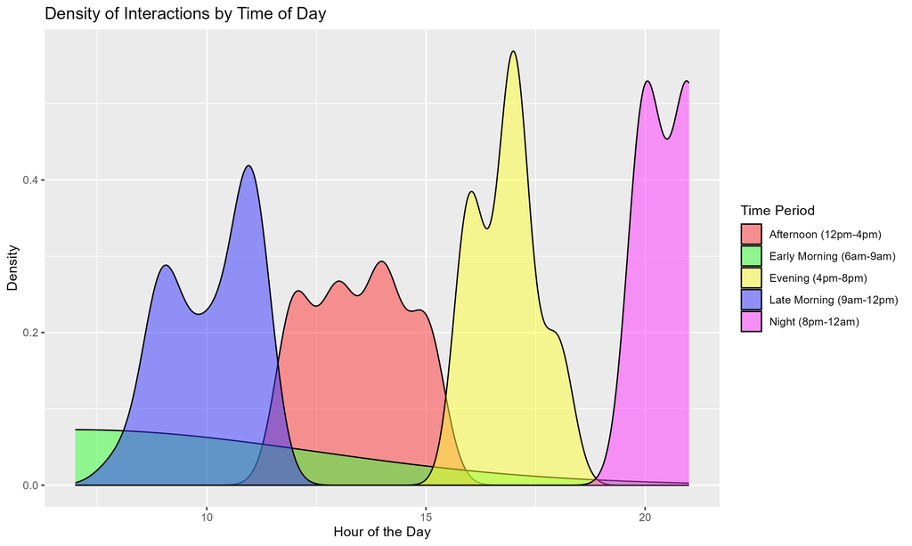

Density Plot

## Device Usage by Interaction Type

This bar plot compares the frequency of different interaction type patterns against the proportion of device use, highlighting which interactions types have devices being more prevalent.

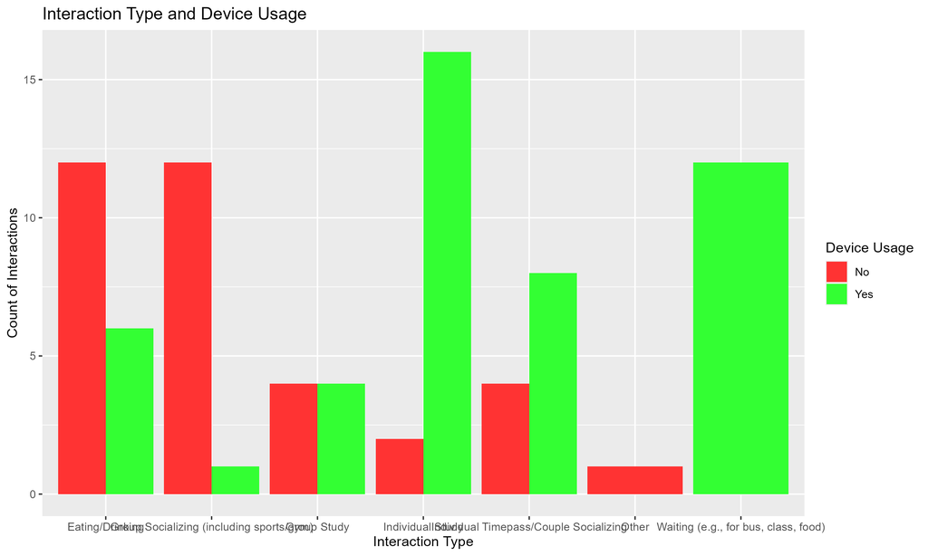

Bar Plot

The bar plot effectively compares interaction types against device usage, revealing key insights into how technology is integrated into different social contexts. Eating/Drinking and Socializing (including sports/gym) interactions exhibit higher counts of interactions without device usage, highlighting a more face-to-face interaction pattern in these contexts. In contrast, Individual Study and Individual Timepass/Couple Socializing show higher instances of device use, indicating that solitary or semi-private interactions are more likely to involve mobile devices or laptops. The Waiting interaction type also shows a significant device usage, suggesting that idle time is frequently filled with mobile interaction. These insights can guide targeted campus policies related to digital engagement and study space design.